# Hypothesis testing

Rakibul Islam Prince

```r
library(pacman)
p_load(dplyr, GGally, ggplot2, ggthemes, ggvis, httr, lubridate, plotly, rio, rmarkdown, shiny, stringr, tidyr)
```

```r
stroke_data<-import("./../data/healthcare-dataset-stroke-data.csv")
stroke_data<-na.omit(stroke_data)
clean_stroke_data<-stroke_data[!apply(stroke_data=="N/A",1,any),]
clean_g_stroke_data<-clean_stroke_data %>%
  filter(gender!="Other")
clean_g_stroke_data$bmi<-as.numeric(clean_g_stroke_data$bmi)
str(clean_g_stroke_data)
```

```
'data.frame':   4908 obs. of  12 variables:
 $ id               : int  9046 31112 60182 1665 56669 53882 10434 60491 12109 12095 ...
 $ gender           : chr  "Male" "Male" "Female" "Female" ...
 $ age              : num  67 80 49 79 81 74 69 78 81 61 ...
 $ hypertension     : int  0 0 0 1 0 1 0 0 1 0 ...
 $ heart_disease    : int  1 1 0 0 0 1 0 0 0 1 ...
 $ ever_married     : chr  "Yes" "Yes" "Yes" "Yes" ...
 $ work_type        : chr  "Private" "Private" "Private" "Self-employed" ...
 $ Residence_type   : chr  "Urban" "Rural" "Urban" "Rural" ...
 $ avg_glucose_level: num  229 106 171 174 186 ...
 $ bmi              : num  36.6 32.5 34.4 24 29 27.4 22.8 24.2 29.7 36.8 ...
 $ smoking_status   : chr  "formerly smoked" "never smoked" "smokes" "never smoked" ...
 $ stroke           : int  1 1 1 1 1 1 1 1 1 1 ...
```

```r
clean_g_stroke_data$hypertension<-as.factor(clean_g_stroke_data$hypertension)
clean_g_stroke_data$heart_disease<-as.factor(clean_g_stroke_data$heart_disease)
clean_g_stroke_data$stroke<-as.factor(clean_g_stroke_data$stroke)
data<-clean_g_stroke_data
sample_n(data,5)
```

| id | gender | age | hypertension | heart_disease | ever_married | work_type | Residence_type | avg_glucose_level | bmi | smoking_status | stroke |
| --- | --- | --- | --- | --- | --- | --- | --- | --- | --- | --- | --- |
| 30620 | Male | 37 | 0 | 0 | No | Private | Urban | 90.95 | 24.6 | smokes | 0 |
| 25878 | Male | 55 | 0 | 0 | Yes | Self-employed | Rural | 97.68 | 47.1 | formerly smoked | 0 |
| 38432 | Female | 64 | 0 | 0 | Yes | Private | Urban | 63.32 | 18.7 | formerly smoked | 0 |
| 48435 | Female | 2 | 0 | 0 | No | children | Rural | 155.14 | 13.7 | Unknown | 0 |
| 63725 | Male | 23 | 0 | 0 | No | Private | Urban | 62.00 | 24.8 | formerly smoked | 0 |

Let’s check wether the mean of average glucose level differs between men and women. null hypothesis H0:mu_1-mu_2 = 0 alternative hypothesis HA:mu_1-mu_2 != 0 (two-sided test) alpha=0.05

```r
avg_glu_m<-data$avg_glucose_level[data$gender=="Male"]
print(paste("male avg glucose level:", mean(avg_glu_m)))
```

```
[1] "male avg glucose level: 108.131720537046"
```

```r
avg_glu_f<-data$avg_glucose_level[data$gender=="Female"]
print(paste("female avg glucose level:", mean(avg_glu_f)))
```

```
[1] "female avg glucose level: 103.329913703832"
```

```r
glu_m_mean<-mean(avg_glu_m)
glu_m_len<-length(avg_glu_m)
glu_m_var<-var(avg_glu_m)
glu_f_mean<-mean(avg_glu_f)
glu_f_len<-length(avg_glu_f)
glu_f_var<-var(avg_glu_m)

mu0=0
mean_diff<- glu_m_mean-glu_f_mean
se<-sqrt(glu_m_var/glu_m_len + glu_f_var/glu_f_len)

t<-(mean_diff - mu0)/se
print(paste("calculate Z-score:", t))
```

```
[1] "calculate Z-score: 3.55782983108098"
```

```r
print(paste("For 95% CI Z-score:", round(qnorm(0.975),3)))
```

```
[1] "For 95% CI Z-score: 1.96"
```

Here, we are seeing that our calculated Z-score is way outside of 95% CI. So, we reject the null hypothesis.

```r
# Confidence Interval
round(mean_diff+c(-1,1)*qnorm(0.975)*se,3)
```

```
[1] 2.157 7.447
```

here 95% interval doesn’t contain 0. so we reject the null hypothesis.

```r
#using R library
t.test(data$avg_glucose_level~data$gender, var.equal=FALSE)
```

```
    Welch Two Sample t-test

data:  data$avg_glucose_level by data$gender
t = -3.6739, df = 4089.7, p-value = 0.0002419
alternative hypothesis: true difference in means between group Female and group Male is not equal to 0
95 percent confidence interval:
 -7.364237 -2.239377
sample estimates:
mean in group Female   mean in group Male
            103.3299             108.1317
```

We believe that average BMI for the population is larger than 30 (regardless of the gender). Let’s check our beliefs:

null hypothesis H0:mu_0=30 alternative hypothesis HA:mu_0>30 (one-sided test) alpha=0.05

```r
bmi= data %>% select(bmi) %>% summarise(mean=mean(bmi), sd=sd(bmi))
bmi
```

| mean | sd |
| --- | --- |
| 28.89456 | 7.85432 |

```r
length(data$bmi)
```

```
[1] 4908
```

```r
mu_o<- 30
alpha<-0.05
z<- (bmi$mean-mu_o)/(bmi$sd/sqrt(length(data$bmi)))

print(paste("calculate Z-score:", z))
```

```
[1] "calculate Z-score: -9.86004516573277"
```

```r
print(paste("For 95% CI Z-score:", round(qnorm(0.95),3)))
```

```
[1] "For 95% CI Z-score: 1.645"
```

calculate z-score is less than .95 quantile.so, we accept the Null hypothesis.

```r
#using R library
t.test(data$bmi, mu=mu_o,alternative="greater")
```

```
    One Sample t-test

data:  data$bmi
t = -9.86, df = 4907, p-value = 1
alternative hypothesis: true mean is greater than 30
95 percent confidence interval:
 28.71012      Inf
sample estimates:
mean of x
 28.89456
```

If the claim is: H0: ratio of strokes among men and women is the same: p_m-p_f =0 HA: ratio of strokes among men and women is different: p_m-p_f !=0 alpha= 0.05

```r
# Number of males and females with stroke
stroke_m <- nrow(data %>% filter(gender == "Male", stroke == 1))
stroke_f <- nrow(data %>% filter(gender == "Female", stroke == 1))

# Total number of males and females
total_m <- nrow(data %>% filter(gender == "Male"))
total_f <- nrow(data %>% filter(gender == "Female"))

# Proportion test
result <- prop.test(x = c(stroke_m, stroke_f), n = c(total_m, total_f), alternative="two.sided")

# Print result
print(result)
```

```
    2-sample test for equality of proportions with continuity correction

data:  c(stroke_m, stroke_f) out of c(total_m, total_f)
X-squared = 0.16955, df = 1, p-value = 0.6805
alternative hypothesis: two.sided
95 percent confidence interval:
 -0.009138838  0.014807694
sample estimates:
    prop 1     prop 2
0.04425659 0.04142216
```

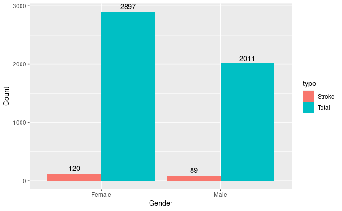

```r
# Create a data frame
bar_data <- data.frame(
  gender = rep(c("Male", "Female"), 2),
  count = c(stroke_m, stroke_f, total_m, total_f),
  type = rep(c("Stroke", "Total"), each = 2)
)

# Create the bar plot
ggplot(bar_data, aes(x = gender, y = count, fill = type)) +
  geom_bar(stat = "identity", position = "dodge") +
  geom_text(aes(label = count), vjust = -0.5, position = position_dodge(0.9)) +
  labs(y = "Count", x = "Gender")
```

```r
print(paste0("Calculated p-value is: ", round(result$p.value, 3)))
```

```
[1] "Calculated p-value is: 0.681"
```

```r
print(paste0("Significance level alpha is: 0.05"))
```

```
[1] "Significance level alpha is: 0.05"
```

As, p-value>alpha : accept H_o That means, proportion of both Males and females having stroke is quite similar.